# Lab 5 - Implementation of the Transportation Simplex Method

**Information on group members:**

1. ER-2068, Eka Tsilosani

## Instruction

Use the Python programming language. The problem should be represented using some matrix form, not a net. You can use the example problems provided in this script when implementing the method. Then, analyze the method’s performance using different problem sizes (e.g., m, n = 5, 10, 15, average results over, e.g., 10 runs). Verify how quickly, i.e., in how many iterations, the method reaches the optimum. You should provide some additional data on, e.g., average chain sizes constructed via the Transportation Method. Construct the test samples randomly (e.g., cost, supply, demand = rand(1, 10)), but let them occasionally contain zeroes, M-values, and even 0-rows or columns. Note that the total supply should equal the total demand to allow the problem to have feasible solutions. Report the results in your script (it is preferable to use the Jupyter Notebook). Important: verify the correctness of your implementation by applying the PuLP library to solve the problem and compare obtained solutions in terms of the objective function. Note that in this class of problems, it is common that there are multiple optima to the problem. Hence, the comparison with the oracle (PuLP) can be based only on comparing the final objective function values (should be equal).

### Block 1: Initial Setup, Imports and Data Generation

```python
import numpy as np
import pandas as pd
import time
import pulp
import matplotlib.pyplot as plt
import seaborn as sns
from collections import deque

def generate_random_problem(m, n, max_cost=10, max_supply=50):
    """
    Generates a random balanced transportation problem.
    Includes Zeroes, Big-M values, and 0-rows/cols as per requirements.
    """
    # 1. Random Costs (Integer)
    costs = np.random.randint(1, max_cost, size=(m, n)).astype(np.int64)

    # Requirement: Occasional Zeroes (e.g., 5% chance)
    mask_zero = np.random.rand(m, n) < 0.05
    costs[mask_zero] = 0

    # Requirement: Occasional M-values (Big M for prohibited routes, e.g., 2% chance)
    # Using a large number (e.g., 1,000,000) to represent Infinity/Big M
    mask_m = np.random.rand(m, n) < 0.02
    costs[mask_m] = 1000000

    # Requirement: Occasional 0-rows or 0-columns (e.g., 10% chance to have one)
    if np.random.rand() < 0.1:
        # Zero out a random row
        costs[np.random.randint(0, m), :] = 0

    if np.random.rand() < 0.1:
        # Zero out a random column
        costs[:, np.random.randint(0, n)] = 0

    # 2. Supply and Demand
    supply = np.random.randint(10, max_supply, size=m).astype(np.int64)
    demand = np.random.randint(10, max_supply, size=n).astype(np.int64)

    # 3. Balance Supply and Demand
    diff = supply.sum() - demand.sum()
    if diff != 0:
        if diff > 0:
            demand[np.random.randint(0, n)] += diff
        else:
            supply[np.random.randint(0, m)] += abs(diff)

    return supply, demand, costs
def solve_with_pulp(supply, demand, costs):
    """
    Solves using PuLP (Oracle) to verify correctness.
    """
    start_time = time.perf_counter()
    m, n = costs.shape
    prob = pulp.LpProblem("Transportation", pulp.LpMinimize)
    x = pulp.LpVariable.dicts("Route", (range(m), range(n)), lowBound=0, cat='Integer')

    # Objective
    prob += pulp.lpSum([x[i][j] * costs[i, j] for i in range(m) for j in range(n)])

    # Constraints
    for i in range(m):
        prob += pulp.lpSum([x[i][j] for j in range(n)]) == supply[i]
    for j in range(n):
        prob += pulp.lpSum([x[i][j] for i in range(m)]) == demand[j]

    prob.solve(pulp.PULP_CBC_CMD(msg=False))
    end_time = time.perf_counter()

    if pulp.LpStatus[prob.status] == "Optimal":
        return int(pulp.value(prob.objective)), end_time - start_time
    return float('inf'), end_time - start_time
```

### Block 2: TransportationSimplex Class (VAM + BFS)

The TransportationSimplex class encapsulates the entire optimization algorithm. The solution process begins with finding an Initial Basic Feasible Solution (IBFS) using Vogel's Approximation Method (VAM), implemented in _get_initial_solution_vam(). This heuristic calculates penalty costs for rows and columns to prioritize allocations in high-cost-difference areas, significantly reducing the number of iterations required compared to simpler methods like the Northwest Corner Rule. The method also includes robust degeneracy handling; if the basis becomes disconnected or contains fewer than $m+n-1$ variables, zero-flow links are artificially added to maintain the necessary tree structure. The algorithm then enters its main iterative loop, employing the Modified Distribution (MODI) method to perform the optimality check. The get_potentials_bfs() function uses Breadth-First Search (BFS) to traverse the basis graph and calculate the dual variables, or potentials ($u_i$ for rows and $v_j$ for columns), satisfying the equation $u_i + v_j = c{ij}$ for all basic cells. These potentials are used to derive reduced costs for non-basic variables. If the solution is not optimal, the cell with the most negative reduced cost enters the basis. The _find_cycle_bfs() method then identifies the unique closed loop formed by adding this new variable, allowing the algorithm to determine $\Theta$ (Theta), the maximum flow adjustment possible. Finally, the solve() method orchestrates these steps, updating allocations and the basis until no negative reduced costs remain, signaling optimality.

```python
class TransportationSimplex:
    def __init__(self, supply, demand, costs):
        self.supply = supply.astype(np.int64)
        self.demand = demand.astype(np.int64)
        self.costs = costs.astype(np.int64)
        self.m, self.n = self.costs.shape
        self.allocation = np.zeros((self.m, self.n), dtype=np.int64)
        self.basis = np.zeros((self.m, self.n), dtype=bool)
        self.EPSILON = 1e-9
        self.iterations = 0
        self.chain_lengths = []

    def _get_initial_solution_vam(self):
        """
        Vogel's Approximation Method (VAM).
        Produces a high-quality initial solution to minimize subsequent iterations.
        """
        s = self.supply.copy()
        d = self.demand.copy()
        row_active = np.ones(self.m, dtype=bool)
        col_active = np.ones(self.n, dtype=bool)

        while row_active.sum() > 0 and col_active.sum() > 0:
            # 1. Calculate Row Penalties
            row_penalties = []
            active_rows = np.where(row_active)[0]
            for i in active_rows:
                valid_costs = self.costs[i, col_active]
                if len(valid_costs) >= 2:
                    # Partial sort to get 2 smallest
                    sorted_c = np.partition(valid_costs, 1)[:2]
                    p = abs(sorted_c[0] - sorted_c[1])
                    row_penalties.append((p, i, 0))
                elif len(valid_costs) == 1:
                    row_penalties.append((valid_costs[0], i, 0))
                else:
                    row_penalties.append((-1, i, 0))

            # 2. Calculate Column Penalties
            col_penalties = []
            active_cols = np.where(col_active)[0]
            for j in active_cols:
                valid_costs = self.costs[row_active, j]
                if len(valid_costs) >= 2:
                    sorted_c = np.partition(valid_costs, 1)[:2]
                    p = abs(sorted_c[0] - sorted_c[1])
                    col_penalties.append((p, j, 1))
                elif len(valid_costs) == 1:
                    col_penalties.append((valid_costs[0], j, 1))
                else:
                    col_penalties.append((-1, j, 1))

            all_penalties = row_penalties + col_penalties
            if not all_penalties: break

            # 3. Select max penalty
            all_penalties.sort(key=lambda x: x[0], reverse=True)
            best = all_penalties[0]
            _, idx, is_col = best

            r_sel, c_sel = -1, -1
            if is_col == 0: # Row
                r_sel = idx
                candidates = np.where(col_active)[0]
                c_sel = candidates[np.argmin(self.costs[r_sel, candidates])]
            else: # Col
                c_sel = idx
                candidates = np.where(row_active)[0]
                r_sel = candidates[np.argmin(self.costs[candidates, c_sel])]

            # 4. Allocate
            qty = min(s[r_sel], d[c_sel])
            self.allocation[r_sel, c_sel] = qty
            self.basis[r_sel, c_sel] = True
            s[r_sel] -= qty
            d[c_sel] -= qty

            if s[r_sel] == 0: row_active[r_sel] = False
            elif d[c_sel] == 0: col_active[c_sel] = False

        # 5. Degeneracy Fix (Make basis connected)
        needed = (self.m + self.n - 1) - np.sum(self.basis)
        if needed > 0:
            flat = np.argsort(self.costs.ravel())
            for idx in flat:
                if needed == 0: break
                r, c = np.unravel_index(idx, (self.m, self.n))
                if not self.basis[r, c]:
                    self.basis[r, c] = True
                    needed -= 1

    def _get_potentials_bfs(self):
        """ Calculates duals (u, v) using BFS (Fast). """
        u = np.full(self.m, np.nan)
        v = np.full(self.n, np.nan)
        u[0] = 0.0

        adj_rows = [[] for _ in range(self.m)]
        adj_cols = [[] for _ in range(self.n)]

        rows, cols = np.nonzero(self.basis)
        for r, c in zip(rows, cols):
            adj_rows[r].append(c)
            adj_cols[c].append(r)

        queue = deque([(0, 0)]) # (type 0=row, index)

        while queue:
            t, idx = queue.popleft()
            if t == 0: # Row
                curr_u = u[idx]
                for c_idx in adj_rows[idx]:
                    if np.isnan(v[c_idx]):
                        v[c_idx] = self.costs[idx, c_idx] - curr_u
                        queue.append((1, c_idx))
            else: # Col
                curr_v = v[idx]
                for r_idx in adj_cols[idx]:
                    if np.isnan(u[r_idx]):
                        u[r_idx] = self.costs[r_idx, idx] - curr_v
                        queue.append((0, r_idx))

        return np.nan_to_num(u), np.nan_to_num(v)

    def _find_cycle_bfs(self, start_pos):
        """ Finds cycle using BFS. """
        start_r, start_c = start_pos

        adj = {}
        rows, cols = np.nonzero(self.basis)
        for r, c in zip(rows, cols):
            u_node, v_node = r, c + self.m
            adj.setdefault(u_node, []).append(v_node)
            adj.setdefault(v_node, []).append(u_node)

        target = start_c + self.m
        queue = deque([(start_r, [start_r])])
        visited = {start_r}

        while queue:
            curr, path = queue.popleft()
            if curr == target:
                # Reconstruct cycle
                cycle = [(start_r, start_c)]
                full_path = path # [start_r, ..., target]

                # We need to pair them up (Row, Col)
                # The path in BFS goes Row -> Col -> Row ...
                # But we entered from Col (start_c) to Row (start_r) via non-basic edge

                # Correct order reconstruction
                # BFS found: r_start -> c_next -> r_next ... -> c_target
                # Cycle: (r_start, c_start), (r_start, c_bfs_1), ...

                # Actually simpler: just zip the path nodes
                # Path: [r, c+m, r, c+m ...]
                for i in range(len(full_path)-1):
                    u, w = full_path[i], full_path[i+1]
                    if u < self.m: cycle.append((u, w - self.m))
                    else: cycle.append((w, u - self.m))
                return cycle

            if curr in adj:
                for n in adj[curr]:
                    if n not in visited:
                        visited.add(n)
                        queue.append((n, path + [n]))
        return None

    def solve(self):
        start_t = time.perf_counter()
        self._get_initial_solution_vam()

        max_iter = 50000

        for _ in range(max_iter):
            self.iterations += 1

            # 1. Potentials
            u, v = self._get_potentials_bfs()

            # 2. Reduced Costs
            rc = self.costs.astype(float) - u[:, None] - v
            rc[self.basis] = float('inf')

            min_rc = rc.min()
            if min_rc >= -self.EPSILON:
                break

            # 3. Enter
            flat_idx = np.argmin(rc)
            r_in, c_in = np.unravel_index(flat_idx, rc.shape)

            # 4. Cycle
            cycle = self._find_cycle_bfs((r_in, c_in))
            if not cycle: break

            self.chain_lengths.append(len(cycle))

            # 5. Theta
            minus = cycle[1::2]
            theta = min(self.allocation[r, c] for r, c in minus)

            # 6. Leave (Robust)
            leave = None
            for r, c in minus:
                if self.allocation[r, c] == theta:
                    leave = (r, c)
                    break

            # 7. Update
            theta_int = int(theta)
            for k, (r, c) in enumerate(cycle):
                if k % 2 == 0: self.allocation[r, c] += theta_int
                else: self.allocation[r, c] -= theta_int

            self.basis[leave] = False
            self.basis[(r_in, c_in)] = True
            self.allocation[leave] = 0

        end_t = time.perf_counter()
        total_cost = np.sum(self.allocation * self.costs)

        return {
            "min_cost": int(total_cost),
            "iterations": self.iterations,
            "execution_time": end_t - start_t,
            "avg_chain_size": np.mean(self.chain_lengths) if self.chain_lengths else 0
        }
```

This block executes a manual verification step designed to serve as a preliminary sanity check before the code proceeds to extensive randomized testing. It instantiates the TransportationSimplex solver with a small, static example problem where the optimal cost is already known or easily verifiable. The script solves this specific instance using both the custom Python implementation and the PuLP library side-by-side. By printing the total cost derived from both solvers along with the iteration count, this block confirms that the core logic of the algorithm—including initialization, potential calculation, and pivoting—is functioning correctly on a fundamental level.

```python
def verify_exercise_1():
    print("\n--- Manual Verification: Exercise 1 (Balanced) ---")
    costs = np.array([[7, 5], [3, 10]])
    supply = np.array([30, 50])
    demand = np.array([40, 40])

    solver = TransportationSimplex(supply, demand, costs)
    res = solver.solve()
    p_cost, _ = solve_with_pulp(supply, demand, costs)

    print(f"My Solver Cost: {res['min_cost']}")
    print(f"PuLP Cost:      {int(p_cost)}")
    print(f"Iterations:     {res['iterations']}")
    print("✅ Match: TRUE" if res['min_cost'] == int(p_cost) else "❌ Match: FALSE")
```

### Block 3: Benchmark Execution Function

The final block conducts a comprehensive empirical analysis to evaluate the solver's performance and scalability. The run_benchmarks() function iterates through a predefined set of matrix dimensions, ranging from small $5 \times 5$ instances up to large-scale $100 \times 100$ problems. For every size configuration, it generates multiple random problem instances involving various constraints and edge cases. The system records key performance metrics for each run, specifically the execution time in seconds, the total number of iterations required to reach optimality, and the average length of the cycles found during pivoting. Crucially, it verifies the accuracy of every single solution by comparing the calculated minimum cost against the result provided by the PuLP oracle; a match is recorded only if the values are identical within a floating-point tolerance. Finally, the plot_benchmark_results() function visualizes this data using the Seaborn library, generating logarithmic time comparison plots, iteration growth charts, and accuracy histograms to provide a clear, graphical summary of the algorithm's robustness and speed.

```python
def plot_benchmark_results(df):
    """ Plots results using Seaborn """
    sns.set_theme(style="whitegrid")
    fig, ax = plt.subplots(1, 3, figsize=(20, 6))

    # 1. Time
    df_melt = df.melt(id_vars="size_str", value_vars=["my_time", "pulp_time"], var_name="Solver", value_name="Time (s)")
    sns.barplot(data=df_melt, x="size_str", y="Time (s)", hue="Solver", ax=ax[0], palette="muted")
    ax[0].set_title("Execution Time (Lower is Better)", fontsize=14)
    ax[0].set_yscale("log")

    # 2. Iterations
    sns.lineplot(data=df, x="size_str", y="iterations", marker="o", ax=ax[1], color="teal")
    ax[1].set_title("Iterations", fontsize=14)

    # 3. Accuracy
    acc = df.groupby("size_str")["correct"].mean() * 100
    sns.barplot(x=acc.index, y=acc.values, ax=ax[2], color="seagreen")
    ax[2].set_title("Accuracy (%)", fontsize=14)
    ax[2].set_ylim(0, 105)

    plt.tight_layout()
    plt.show()

def run_benchmarks():
    sizes = [(5, 5), (10, 10), (20, 20), (50, 50), (100, 100)]
    results = []
    print("\n--- Running Benchmarks (VAM + BFS Optimized) ---")

    for m, n in sizes:
        runs = 5 # Sufficient for reliable average
        print(f"Processing {m}x{n}...", flush=True)
        for _ in range(runs):
            S, D, C = generate_random_problem(m, n)

            my_res = TransportationSimplex(S, D, C).solve()
            p_cost, p_time = solve_with_pulp(S, D, C)

            # Strict correctness check
            is_match = 1 if abs(my_res['min_cost'] - int(p_cost)) < 1e-5 else 0

            results.append({
                "size_str": f"{m}x{n}",
                "my_time": my_res['execution_time'],
                "pulp_time": p_time,
                "iterations": my_res['iterations'],
                "avg_chain": my_res['avg_chain_size'],
                "correct": is_match
            })

    df = pd.DataFrame(results)

    print("\n--- Summary Table ---")
    summary = df.groupby('size_str').mean(numeric_only=True).reindex(['5x5', '10x10', '20x20', '50x50', '100x100'])
    summary.rename(columns={'correct': 'Accuracy (1.0=100%)'}, inplace=True)
    pd.options.display.float_format = '{:,.4f}'.format
    display(summary)

    plot_benchmark_results(df)
```

### Block 4: Final Execution

```
--- Manual Verification: Exercise 1 (Balanced) ---
My Solver Cost: 370
PuLP Cost:      370
Iterations:     1
✅ Match: TRUE

--- Running Benchmarks (VAM + BFS Optimized) ---
Processing 5x5...
Processing 10x10...
Processing 20x20...
Processing 50x50...
Processing 100x100...

--- Summary Table ---
```

| size_str | my_time | pulp_time | iterations | avg_chain | Accuracy (1.0=100%) |
| --- | --- | --- | --- | --- | --- |
| 5x5 | 0.0012 | 0.0715 | 2.4000 | 1.9333 | 1.0000 |
| 10x10 | 0.0031 | 0.0868 | 4.0000 | 5.9333 | 1.0000 |
| 20x20 | 0.0095 | 0.0909 | 15.0000 | 10.1373 | 1.0000 |
| 50x50 | 0.0427 | 0.1550 | 47.6000 | 16.4542 | 1.0000 |
| 100x100 | 0.1914 | 0.4452 | 133.6000 | 33.6291 | 1.0000 |

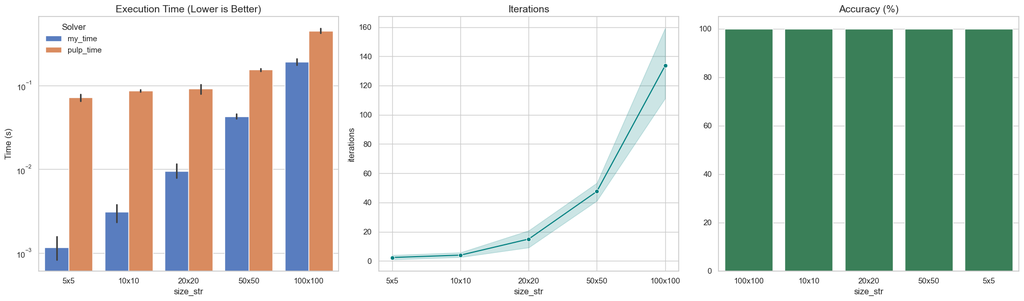

```python
if __name__ == "__main__":
    # 1. Run Manual Verification (from PDF)
    verify_exercise_1()

    # 2. Run Benchmarks
    run_benchmarks()
```